# Catering for prawns, in pursuit of sustainability in the aquaculture industry

Omar Mendoza Porras

CSIRO Livestock and Aquaculture

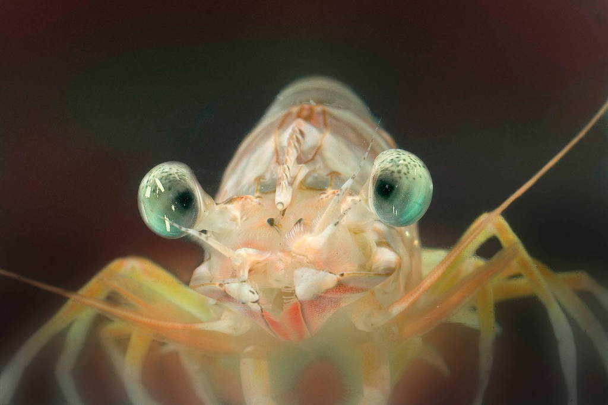

# Introduction

I am an oceanographer with experience in biotechnology, mass spectrometry and aquaculture. Before Data School I did not code at all and my data processing consisted of using vendor specific software (expensive licenses) to visualise and process data. I also did lots of clicking and data sorting in Excel. It was not enjoyable.

# My Project

The goal of my project(s) is to identify peptide markers derived from proteins that are expressed in different prawn tissues as a result of using different functional diets. Proteomics is used as a main tool. The long term goal is to achieve sustainability in the aquaculture sector throughout the use of diets manufactured from renewable sources.

## Preliminary results

In this study, 252 protein peptides were measured in prawn hepatopancreas two hours post-feeding. We used Sequential Window Acquisition of all Theoretical mass spectra (SWATH-MS) to detect and identify these protein peptides.

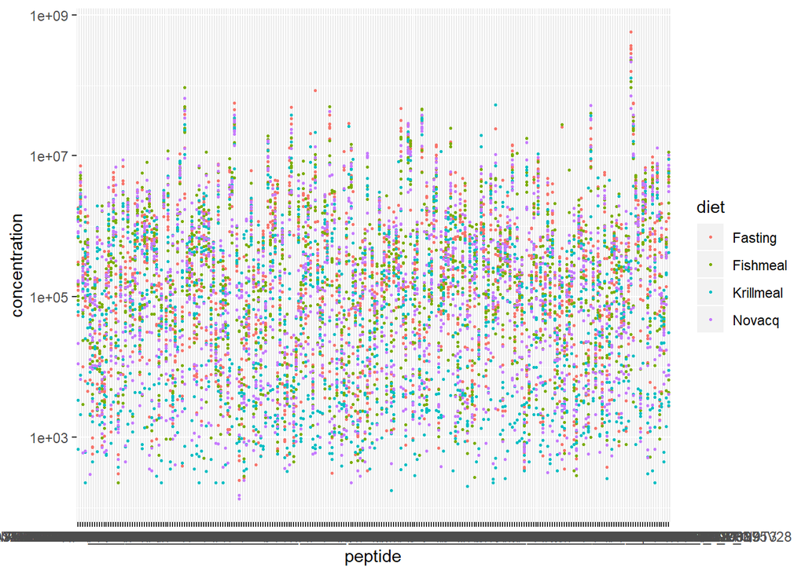

**Tables**

Table 1: Differential protein expression in hepatopancreas of black tiger prawn *Penaeus monodon* in response to specific feeding formulations

| diet | replicate | peptide | concentration |
| --- | --- | --- | --- |
| Fasting | 1 | ADSFDPEANLSHYSDGGK_G1AP69 | 2098.75 |
| Fishmeal | 1 | ADSFDPEANLSHYSDGGK_G1AP69 | 591538.29 |
| Krillmeal | 1 | ADSFDPEANLSHYSDGGK_G1AP69 | 445057.79 |
| Novacq | 1 | ADSFDPEANLSHYSDGGK_G1AP69 | 573059.70 |

**Plots from R**

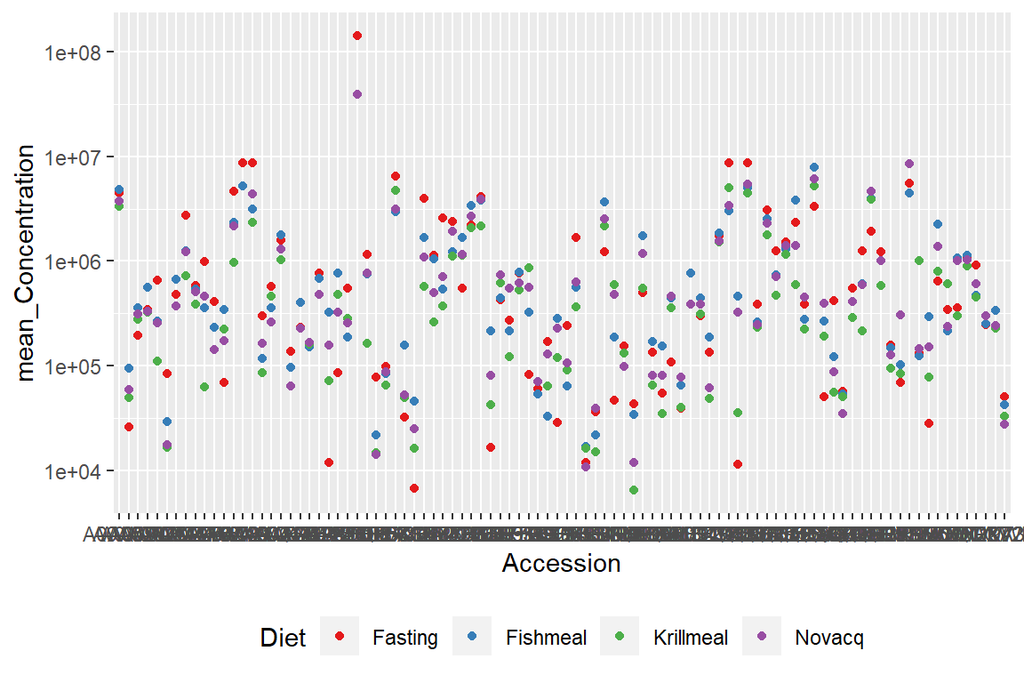

Figure 1: Protein expression in hepatopancreas of prawns fed different diets

# Statistics

Welch Two Sample t-test

data: mean_Concentration by Diet t = -0.68083, df = 114.48, p-value = 0.4974 alternative hypothesis: true difference in means is not equal to 0 95 percent confidence interval: -1228733.0 600152.9 sample estimates: mean in group Fishmeal mean in group Novacq 1045628 1359918

Welch Two Sample t-test

data: mean_Concentration by Diet t = -1.4118, df = 106.67, p-value = 0.1609 alternative hypothesis: true difference in means is not equal to 0 95 percent confidence interval: -1536256.4 258288.2 sample estimates: mean in group Krillmeal mean in group Novacq 720934 1359918

Welch Two Sample t-test

data: mean_Concentration by Diet t = 0.88402, df = 106.77, p-value = 0.3787 alternative hypothesis: true difference in means is not equal to 0 95 percent confidence interval: -1749426 4565366 sample estimates: mean in group Fasting mean in group Novacq 2767888 1359918

# My Digital Toolbox

The tool that I have used the most in my projects is Tidyverse. I currenlty use it to generate lists of proteins identified using proteomics and to filter protein redundancy. I am also focusing on learning more about ggplot2

# My time went …

I spent a significant amount of time understanding the underlying logic of the process of making dataframes “tidy”. I was not surprised that Data School would be a challenge but at the same time I was very excited to start learning a coding language. I solved some of my challenges by rewatching the webex recordings and reading at forums in the internet.

# Next steps

I will focus in mastering R for now but I am sure that I am not going back to excel. I believe that in the future I would like to become a bioinformatician/statistician to complement my current skills. I would like to learn bash, SQL, SAS and python.

# My Data School Experience

I wish I had attended week 1 at data school to personally meet everyone. Aside from that my experience in data school has been rich. I have been able to use my newly acquired data school skills in my daily work. A specific example of this has been producing an output (a protein list) that tells me the degree of protein redundancy that I have in my proteomics work. This was a task that would take me between 3-4 hours in excel. Now it takes me 45 seconds. Very embarrasing. Never again. At a personal level, being able to be more efficient with my time makes me feel more at ease and happy.